# Prediction Final Assignment2

Anais Gentilhomme

July 27, 2018

## Background

Using devices such as Jawbone Up, Nike FuelBand, and Fit it is not possible to collect a large amount of data about personal activity relatively inexpensively. THese type of devices are part of te quantified self movement- a group of enthusiasts who take measurements about themselves regularly to improve their health, to find patters in their behavior, or because they are tech geeks. One thing that people regularly do is quantify how much of a particular activity they do, but they rarey quantify how well they do it. In this project, your goal will be to use data from accelerometers on the belt, forearm, arm, and dumbell of 6 participants. They were asked to perform barbell lifts correctly and incorrectly in 5 ways:  
1. Class A: Correct, according to specifications  
2. Class B: Incorrect, throwing the elbow to the front  
3. Class C: Incorrect, lifting the dumbbell only halfway  
4. Class D: Incorrect, lowering the dumbell only halfway  
5. Class E: Incorrect, throwing the hips to the front

# Preliminary Analysis

## Loading the Testing and Training Data and Cleaning it up

```r
TrainingData <- read.csv("pml-training (1).csv", header = TRUE, na.strings = c("NA", "","#DIV/0!"))
TestingData <- read.csv("pml-testing.csv", header = TRUE, na.strings = c("NA", "","#DIV/0!"))
dim(TrainingData)
```

```
## [1] 19622   160
```

```r
dim(TestingData)
```

```
## [1]  20 160
```

```r
# Find the columns that have all missing values and delete them
TrainingData <- TrainingData[,colSums(is.na(TrainingData)) == 0]
TestingData <- TestingData[,colSums(is.na(TestingData)) == 0]

#Equalize the amount of predictors between the Training and Testing Data set( for the final simulation)
TrainingData <- TrainingData[, -c(1:7)]
TestingData <- TestingData[,-c(1:7)]
```

## Seperating the Data

Here we seperate the data into two data sets, 75% for Training and 25% for Testing

```r
SampleData <- createDataPartition(y=TrainingData$classe, p=0.75, list = FALSE)
SampleTraining <- TrainingData[SampleData,]
SampleTesting <- TrainingData[-SampleData,]
dim(SampleTraining)
```

```
## [1] 14718    53
```

```r
dim(SampleTesting)
```

```
## [1] 4904   53
```

## The Data at a Glance

In order to get a idea of how frequently the exercise are being done correctly(variable:classe), a bar graph is presented below.

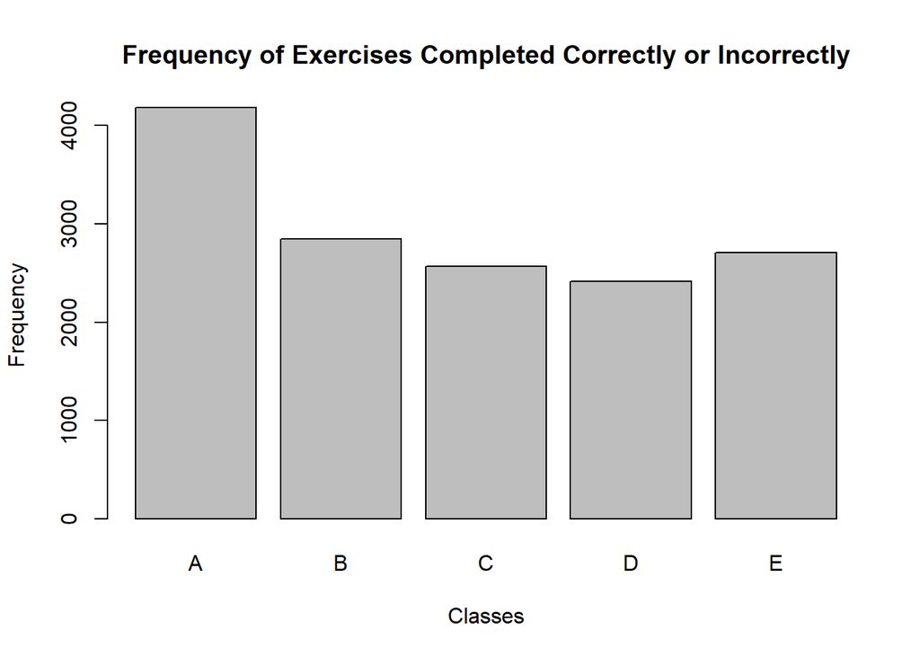

```r
plot(SampleTraining$classe, main = "Frequency of Exercises Completed Correctly or Incorrectly", xlab = "Classes", ylab = "Frequency" )
```

```r
RF <- randomForest(classe~., data = SampleTraining)
TrainingPredict <- predict(RF, SampleTraining)
print(confusionMatrix(TrainingPredict,SampleTraining$classe))
```

```
## Confusion Matrix and Statistics
##
##           Reference
## Prediction    A    B    C    D    E
##          A 4185    0    0    0    0
##          B    0 2848    0    0    0
##          C    0    0 2567    0    0
##          D    0    0    0 2412    0
##          E    0    0    0    0 2706
##
## Overall Statistics
##
##                Accuracy : 1
##                  95% CI : (0.9997, 1)
##     No Information Rate : 0.2843
##     P-Value [Acc > NIR] : < 2.2e-16
##
##                   Kappa : 1
##  Mcnemar's Test P-Value : NA
##
## Statistics by Class:
##
##                      Class: A Class: B Class: C Class: D Class: E
## Sensitivity            1.0000   1.0000   1.0000   1.0000   1.0000
## Specificity            1.0000   1.0000   1.0000   1.0000   1.0000
## Pos Pred Value         1.0000   1.0000   1.0000   1.0000   1.0000
## Neg Pred Value         1.0000   1.0000   1.0000   1.0000   1.0000
## Prevalence             0.2843   0.1935   0.1744   0.1639   0.1839
## Detection Rate         0.2843   0.1935   0.1744   0.1639   0.1839
## Detection Prevalence   0.2843   0.1935   0.1744   0.1639   0.1839
## Balanced Accuracy      1.0000   1.0000   1.0000   1.0000   1.0000
```

This model works extremely well with the Training Dataset with an accuracy rate of 1. However, in order for it to be legitamate we need to cross validate it with the Testing Data set that was isolated earlier.

## Cross - Validation

```r
TestingPredict <- predict(RF, SampleTesting)
print(confusionMatrix(TestingPredict,SampleTesting$classe))
```

```
## Confusion Matrix and Statistics
##
##           Reference
## Prediction    A    B    C    D    E
##          A 1394    3    0    0    0
##          B    1  944   10    0    0
##          C    0    2  845    7    0
##          D    0    0    0  797    0
##          E    0    0    0    0  901
##
## Overall Statistics
##
##                Accuracy : 0.9953
##                  95% CI : (0.993, 0.997)
##     No Information Rate : 0.2845
##     P-Value [Acc > NIR] : < 2.2e-16
##
##                   Kappa : 0.9941
##  Mcnemar's Test P-Value : NA
##
## Statistics by Class:
##
##                      Class: A Class: B Class: C Class: D Class: E
## Sensitivity            0.9993   0.9947   0.9883   0.9913   1.0000
## Specificity            0.9991   0.9972   0.9978   1.0000   1.0000
## Pos Pred Value         0.9979   0.9885   0.9895   1.0000   1.0000
## Neg Pred Value         0.9997   0.9987   0.9975   0.9983   1.0000
## Prevalence             0.2845   0.1935   0.1743   0.1639   0.1837
## Detection Rate         0.2843   0.1925   0.1723   0.1625   0.1837
## Detection Prevalence   0.2849   0.1947   0.1741   0.1625   0.1837
## Balanced Accuracy      0.9992   0.9960   0.9930   0.9956   1.0000
```

## Final Testing

```r
FinalTest <- predict(RF, TestingData, type = "class")
FinalTest
```

```
##  1  2  3  4  5  6  7  8  9 10 11 12 13 14 15 16 17 18 19 20
##  B  A  B  A  A  E  D  B  A  A  B  C  B  A  E  E  A  B  B  B
## Levels: A B C D E
```

Writting files for Submission

```r
pml_write_files = function(x){
  n = length(x)
  for(i in 1:n){
    ProjectName <- paste0("problem_id_",i,".txt")
    write.table(x[i], file = ProjectName,quote = FALSE,row.names = FALSE,col.names = FALSE)
  }
}

pml_write_files(FinalTest)
```